# Exam_Notes

Elwood Fong

2025-04-13

## Library Initialization

```r
library(tidyr)
library(dplyr)
library(ggplot2)
library(ggalt)
library(naniar)
```

## Data Initialization

```r
data <- iris
# data <- read.csv("FilePath\to\csvFile")

# Artificially Add Column
data$Size <- ifelse(data$Sepal.Length > 5, "Large", "Small")
```

### Assumptions

> We ALWAYS assume that observations (rows of data) are independent.

## Data Cleaning

### Convert “character” to factor (Turns it Categorical)

```r
data$Size <- as.factor(data$Size)
```

### Visualizing Missingness of Data

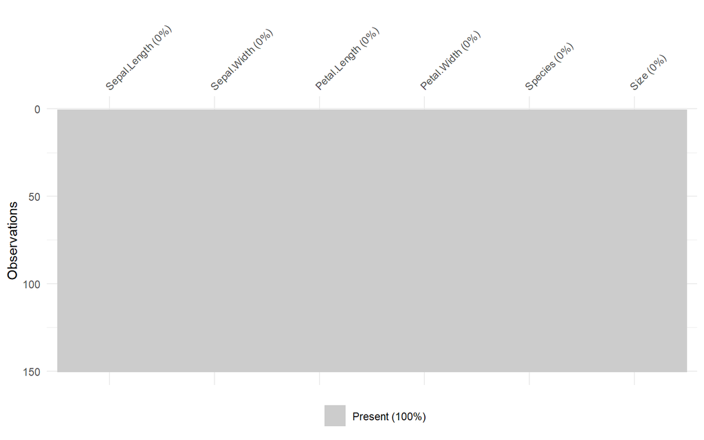

```r
vis_miss(data)
```

### Remove NA Values

```r
data <- na.omit(data)
```

### Getting Dimensions of Data (See Observations and Variables)

```r
dim(data)
```

```
## [1] 150   6
```

```r
# Outputs:
# Observations: 150    Variables: 6
```

### Changing Data Dimensions

```r
grouped_data <- data
grouped_data %>%
  group_by(Species) %>%
  summarise(
    mean_Petal.Length = mean(Petal.Length, na.rm = TRUE),
    median_Petal.Length = median(Petal.Length, na.rm = TRUE))
```

```
## # A tibble: 3 × 3
##   Species    mean_Petal.Length median_Petal.Length
##   <fct>                  <dbl>               <dbl>
## 1 setosa                  1.46                1.5
## 2 versicolor              4.26                4.35
## 3 virginica               5.55                5.55
```

```r
grouped_data <- data
grouped_data %>%
  group_by(Species) %>%
  summarise(
    mean_Petal.Length = mean(Petal.Length, na.rm = TRUE),
    median_Petal.Length = median(Petal.Length, na.rm = TRUE)) %>%
  pivot_longer(cols=c("mean_Petal.Length", "median_Petal.Length"), names_to="summary", values_to="length")
```

```
## # A tibble: 6 × 3
##   Species    summary             length
##   <fct>      <chr>                <dbl>
## 1 setosa     mean_Petal.Length     1.46
## 2 setosa     median_Petal.Length   1.5
## 3 versicolor mean_Petal.Length     4.26
## 4 versicolor median_Petal.Length   4.35
## 5 virginica  mean_Petal.Length     5.55
## 6 virginica  median_Petal.Length   5.55
```

### Scaling Data

```r
ScaledData <- data %>%
  dplyr::select(-Species, -Size) %>%
  scale()
head(ScaledData)
```

```
##   Sepal.Length Sepal.Width Petal.Length Petal.Width
## 1   -0.8976739  1.01560199    -1.335752   -1.311052
## 2   -1.1392005 -0.13153881    -1.335752   -1.311052
## 3   -1.3807271  0.32731751    -1.392399   -1.311052
## 4   -1.5014904  0.09788935    -1.279104   -1.311052
## 5   -1.0184372  1.24503015    -1.335752   -1.311052
## 6   -0.5353840  1.93331463    -1.165809   -1.048667
```

```r
# Output:
# Table of Scaled Data
# Should only be done with numerical variables
```

## Reading Data

### Get Row with Minimum Petal.Length

```r
library(tidyr)
data %>%
  filter(data$Petal.Length==min(data$Petal.Length))
```

```
##   Sepal.Length Sepal.Width Petal.Length Petal.Width Species  Size
## 1          4.6         3.6            1         0.2  setosa Small
```

### Count Number of NA Values

```r
sum(is.na(data))
```

```
## [1] 0
```

```r
# Outputs:
# Number of NA values: 0
```

### Count Number of rows with NA Values

```r
sum(!complete.cases(data))
```

```
## [1] 0
```

```r
# Outputs:
# Number of rows with NA values: 0
```

### Check Variable Data Types

```r
sapply(data,class)
```

```
## Sepal.Length  Sepal.Width Petal.Length  Petal.Width      Species         Size
##    "numeric"    "numeric"    "numeric"    "numeric"     "factor"     "factor"
```

```r
# Outputs:
# Sepal.Length  Sepal.Width Petal.Length  Petal.Width       Species         Size
#    "numeric"    "numeric"    "numeric"    "numeric"      "factor"      "factor"

# Type of Variable:
# Sepal.Length  Sepal.Width Petal.Length  Petal.Width       Species         Size
#  "numerical"  "numerical"  "numerical"  "numerical" "categorical" "categorical"
```

### Constructing a Contingency Table

```r
contingency_table <- table(data$Species, data$Size)
contingency_table
```

```
##
##              Large Small
##   setosa        22    28
##   versicolor    47     3
##   virginica     49     1
```

## Analyzing Data

### Chi-Squared Test

#### Requirements

- Comparing 2 CATEGORICAL variables
- H<sub>0</sub> = Null Hypothesis
  - There is no relationship between variables
  - TRUE only if `p-value` > 0.05
- H<sub>a</sub> = Alternate Hypothesis
  - There is a relationship between variables
  - TRUE only if `p-value` < 0.05

#### Application

```r
chisq_tab <- table(data$Species, data$Size)
chisq_result = chisq.test(chisq_tab)
chisq_result
```

```
##
##  Pearson's Chi-squared test
##
## data:  chisq_tab
## X-squared = 53.946, df = 2, p-value = 1.931e-12
```

#### Chi-Squared Test Result Components

| R Code | Meaning / Description | Interpretation / Usage |
| --- | --- | --- |
| `chisq_result$statistic` | Chi-squared Test Statistic (X²) | Higher value → More difference between observed and expected counts and stronger evidence against H₀ |
| `chisq_result$parameter` | Degrees of Freedom (df) | Depends on table size: (rows-1) × (cols-1) → just tells you how many categories you’re comparing |
| `chisq_result$p.value` | P-value (significance level) | Small p-value (< 0.05) → Reject H₀ |
| `chisq_result$observed` | Observed counts from your data | Actual values in your data table |
| `chisq_result$expected` | Expected counts under the null hypothesis | What values you’d expect if no association, if Expected Count ≥ 5 → The Chi-squared test is reliable. |
| `chisq_result$residuals` | Raw Residuals = (Observed - Expected) / sqrt(Expected) | Measures difference between observed and expected → if bigger, then stronger evidence against H₀ |
| `chisq_result$stdres` | Standardized Residuals (scaled residuals) → | Values Between -2 and 2 supports H₀, Bigger than 2 or less than -2 supports H<sub>a</sub> |

```r
chisq_result$statistic       # Test statistic
```

```
## X-squared
##  53.94597
```

```r
chisq_result$parameter       # Degrees of freedom
```

```
## df
##  2
```

```r
chisq_result$p.value         # P-value
```

```
## [1] 1.930992e-12
```

```r
chisq_result$observed        # Observed table
```

```
##
##              Large Small
##   setosa        22    28
##   versicolor    47     3
##   virginica     49     1
```

```r
chisq_result$expected        # Expected counts
```

```
##
##                 Large    Small
##   setosa     39.33333 10.66667
##   versicolor 39.33333 10.66667
##   virginica  39.33333 10.66667
```

```r
chisq_result$residuals       # Residuals
```

```
##
##                  Large     Small
##   setosa     -2.763769  5.307228
##   versicolor  1.222436 -2.347428
##   virginica   1.541333 -2.959800
```

```r
chisq_result$stdres          # Standardized residuals
```

```
##
##                  Large     Small
##   setosa     -7.328549  7.328549
##   versicolor  3.241473 -3.241473
##   virginica   4.087075 -4.087075
```

#### Chi-Squared Test Result Analysis

```r
chisq_result$stdres > 2 | chisq_result$stdres < -2
```

```
##
##              Large Small
##   setosa      TRUE  TRUE
##   versicolor  TRUE  TRUE
##   virginica   TRUE  TRUE
```

### K Means Clustering

> Requires Data Scaling from data scaling

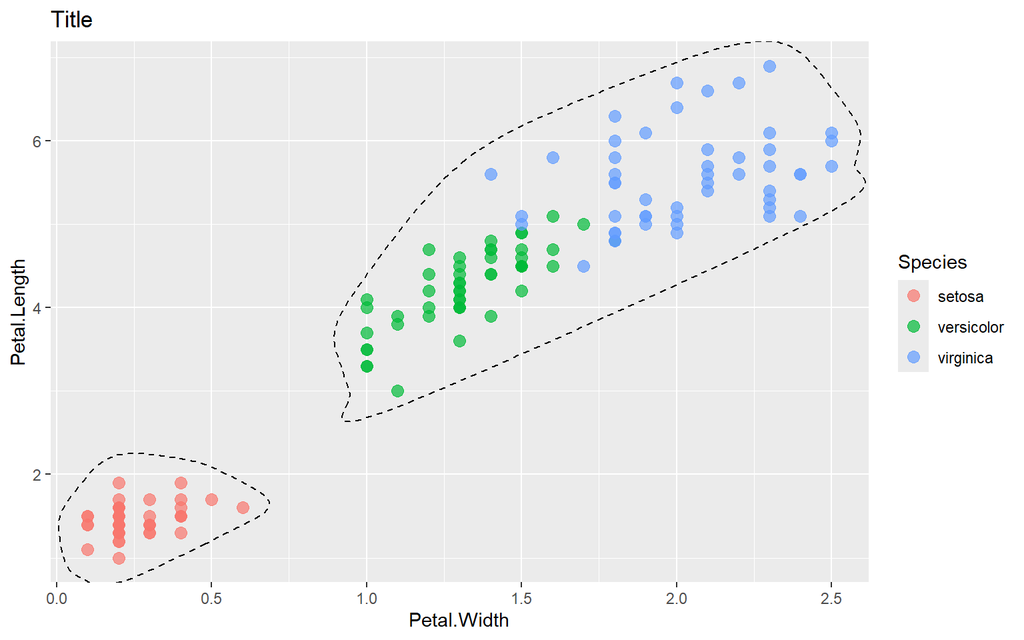

```r
set.seed(256)

k_means_data <- data

kmeans_result <- kmeans(ScaledData, centers = 2)

k_means_data$cluster <- as.factor(kmeans_result$cluster)

ggplot(k_means_data, aes(x = Petal.Width, y = Petal.Length, color = Species)) +
  geom_point(size = 3, alpha = 0.7) +
  geom_encircle(aes(group = cluster), expand = 0.05, spread = 0.05,
                color = "black", linetype = "dashed", size = 1.2) +
  labs(title = "Title",
       x = "Petal.Width", y = "Petal.Length")
```

### ANOVA

#### Requirements

- Comparing 1 CATEGORICAL and 1 NUMERICAL variable
- H<sub>0</sub> = Null Hypothesis
  - There is no relationship between variables
  - TRUE only if `p-value` > 0.05
- H<sub>a</sub> = Alternate Hypothesis
  - There is a relationship between variables
  - TRUE only if `p-value` < 0.05

#### ANOVA Result Componenets

| ANOVA Output Column | Meaning / Description | Interpretation / Usage |
| --- | --- | --- |
| `Df` | Degrees of Freedom | Number of groups - 1 for factor; Number of observations - groups for residuals |
| `Sum Sq` | Sum of Squares | Total variation explained by factor or left in residuals |
| `Mean Sq` | Mean Square = Sum Sq / Df | Average variation per degree of freedom |
| `F value` | F-statistic = Mean Sq of Factor / Mean Sq of Residuals | Higher value → Stronger evidence against H₀ (factor affects response variable) |
| `Pr(>F)` | P-value for F-statistic | Small p-value (< 0.05) → Reject H₀ → Factor has significant effect |

#### 1 way ANOVA

```r
anova_result = aov(Petal.Width~Species, data)
summary(anova_result)
```

```
##              Df Sum Sq Mean Sq F value Pr(>F)
## Species       2  80.41   40.21     960 <2e-16 ***
## Residuals   147   6.16    0.04
## ---
## Signif. codes:  0 '***' 0.001 '**' 0.01 '*' 0.05 '.' 0.1 ' ' 1
```

1. Species:
- Df = 2 → There are 3 species groups (k-1 = 3-1 = 2).
- Sum Sq = 80.41 → Most of the variation comes from the species differences.
- F value = 960 → This is huge. It means the variation between species is much bigger than the variation within species.
- p-value < 2e-16 → This is basically 0. Very statistically significant (*** means p < 0.001).

Conclusion: The species groups have significantly different means.

2. Residuals:
- Df = 147 → There were 150 total observations (because N-k = 147, so N=147+3=150).
- Sum Sq = 6.16 → Only a small amount of variation comes from randomness within species.
- Mean Sq = 0.04 → Very small — shows low within-group variability.

#### 2 way ANOVA

```r
aov_2_result <- aov(Petal.Width ~ Species + Size, data)
summary(aov_2_result)
```

```
##              Df Sum Sq Mean Sq F value Pr(>F)
## Species       2  80.41   40.21 993.187 <2e-16 ***
## Size          1   0.25    0.25   6.081 0.0148 *
## Residuals   146   5.91    0.04
## ---
## Signif. codes:  0 '***' 0.001 '**' 0.01 '*' 0.05 '.' 0.1 ' ' 1
```

Same analysis as above (do the same for Size) but with the following conlusion:

“Species matters a lot more than size in this data. Size still has a small effect, but species differences explain most of the variation. Both species and size are statistically significant.”

#### Additional Test AFTER ANOVA

```r
TukeyHSD(aov_2_result)
```

```
##   Tukey multiple comparisons of means
##     95% family-wise confidence level
##
## Fit: aov(formula = Petal.Width ~ Species + Size, data = data)
##
## $Species
##                      diff       lwr       upr p adj
## versicolor-setosa    1.08 0.9847161 1.1752839     0
## virginica-setosa     1.78 1.6847161 1.8752839     0
## virginica-versicolor 0.70 0.6047161 0.7952839     0
##
## $Size
##                    diff        lwr          upr     p adj
## Small-Large -0.07913136 -0.1583863 0.0001235398 0.0503535
```

All species pairs are significantly different from each other (p-value = 0). - Note that the difference between virginica and setosa is the largest.